None

# Рекомендация тарифов

## Введение

В нашем распоряжении данные о поведении клиентов, которые уже перешли на эти тарифы (из проекта курса «Статистический анализ данных»).

**Цель:** Нужно построить модель для задачи классификации, которая выберет подходящий тариф.

Предобработка данных не понадобится — мы её уже сделали.

*Важно:*

- Построим модель с максимально большим значением *accuracy*. Оптимизируем время выполнения, где это возможно.
- Чтобы сдать проект успешно, нужно довести долю правильных ответов по крайней мере до 0.75.
- Проверим *accuracy* на тестовой выборке.

**Замечание**: ниже, одной из метрик мы взяли *время выполнения*, но во время исполнения проекта эта метрика оказалась, слишком сильно зависящей от аппаратной части и выборок. Но я оставил рассуждения, так как сам процесс работы с этой метрикой был интересен и познавателен. К сожалению, следствием может быть не полное соответствие выводов результатов выполнения кода.

## Библиотеки

Ниже будут указаны библиотеки и их части, которые мы используем для реализации проекта.

```python
import pandas as pd
# для модели проверки адекватности
from numpy.random import choice
# для графиков
import matplotlib.pyplot as plt
# метрика время исполнения
import time

# для разделения данных на выборки
from sklearn.model_selection import train_test_split
# метрика для моделей- accuracy
from sklearn.metrics import accuracy_score
# Классификатор Дерево решений
from sklearn.tree import DecisionTreeClassifier
from sklearn.tree import plot_tree
# Классификатор Случайный Лес
from sklearn.ensemble import RandomForestClassifier
# Классификатор Логистическая регрессия
from sklearn.linear_model import LogisticRegression
# Классификатор для проверки адекватности
from sklearn.dummy import DummyClassifier


# для скрытия ошибок
import warnings
warnings.filterwarnings("ignore")

# для увеличения окна вывода
pd.options.display.max_rows = 300
```

## Откройте и изучите файл

Откроем файл. Проверим корректность его открытия.

```python
# версия для ревьюера
# df = pd.read_csv('/datasets/users_behavior.csv')
# локальная версия
df = pd.read_csv('users_behavior.csv')
```

```python
df.head()
```

|  | calls | minutes | messages | mb_used | is_ultra |
| --- | --- | --- | --- | --- | --- |
| 0 | 40.0 | 311.90 | 83.0 | 19915.42 | 0 |
| 1 | 85.0 | 516.75 | 56.0 | 22696.96 | 0 |
| 2 | 77.0 | 467.66 | 86.0 | 21060.45 | 0 |
| 3 | 106.0 | 745.53 | 81.0 | 8437.39 | 1 |
| 4 | 66.0 | 418.74 | 1.0 | 14502.75 | 0 |

Проверим наши данные.

```python
# Напишем фунцию для получения информации о данных
def data_frame_info (data_frame):
    list_c = data_frame.columns #['calls', 'minutes', 'messages', 'mb_used', 'is_ultra']
    display('Количество явных дубликатов:', data_frame.duplicated().sum())
    display('-'* 25)

    display(data_frame.info())
    display('-'* 25)

    display(data_frame.hist())
    plt.title('Гистограммы для данных в столбцах')
    plt.show()
    display('-'* 25)

    display(data_frame.corr())
    display('-'* 25)

    pd.plotting.scatter_matrix(data_frame)
    plt.title('Попарные графики распределения')
    plt.show()


    for col_l in list_c:
        display('-'* 25)
        display('Информация для колоки', col_l)
        display(data_frame[col_l].describe())
        display('-'* 25)
        display(col_l, data_frame[col_l].sort_values().unique())
        display(col_l,': кол-во NaN',data_frame[col_l].isna().sum(),
            ', процент NaN', round(data_frame[col_l].isna().sum()/len(df)*100, 2),'%')
```

```
'Количество явных дубликатов:'
```

```
0
```

```
'-------------------------'
```

```
<class 'pandas.core.frame.DataFrame'>
RangeIndex: 3214 entries, 0 to 3213
Data columns (total 5 columns):
 #   Column    Non-Null Count  Dtype
---  ------    --------------  -----
 0   calls     3214 non-null   float64
 1   minutes   3214 non-null   float64
 2   messages  3214 non-null   float64
 3   mb_used   3214 non-null   float64
 4   is_ultra  3214 non-null   int64
dtypes: float64(4), int64(1)
memory usage: 125.7 KB
```

```
None
```

```
'-------------------------'
```

```
array([[<AxesSubplot:title={'center':'calls'}>,
        <AxesSubplot:title={'center':'minutes'}>],
       [<AxesSubplot:title={'center':'messages'}>,
        <AxesSubplot:title={'center':'mb_used'}>],
       [<AxesSubplot:title={'center':'is_ultra'}>, <AxesSubplot:>]],
      dtype=object)
```

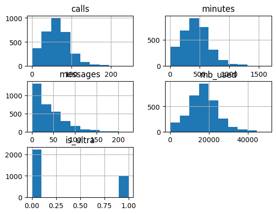

```
'-------------------------'
```

|  | calls | minutes | messages | mb_used | is_ultra |
| --- | --- | --- | --- | --- | --- |
| calls | 1.000000 | 0.982083 | 0.177385 | 0.286442 | 0.207122 |
| minutes | 0.982083 | 1.000000 | 0.173110 | 0.280967 | 0.206955 |
| messages | 0.177385 | 0.173110 | 1.000000 | 0.195721 | 0.203830 |
| mb_used | 0.286442 | 0.280967 | 0.195721 | 1.000000 | 0.198568 |
| is_ultra | 0.207122 | 0.206955 | 0.203830 | 0.198568 | 1.000000 |

```
'-------------------------'
```

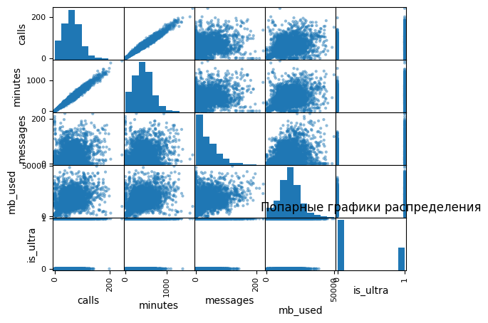

```
'-------------------------'
```

```
'Информация для колоки'
```

```
'calls'
```

```
count    3214.000000
mean       63.038892
std        33.236368
min         0.000000
25%        40.000000
50%        62.000000
75%        82.000000
max       244.000000
Name: calls, dtype: float64
```

```
'-------------------------'
```

```
'calls'
```

```
array([  0.,   1.,   2.,   3.,   4.,   5.,   6.,   7.,   8.,   9.,  10.,
        11.,  12.,  13.,  14.,  15.,  16.,  17.,  18.,  19.,  20.,  21.,
        22.,  23.,  24.,  25.,  26.,  27.,  28.,  29.,  30.,  31.,  32.,
        33.,  34.,  35.,  36.,  37.,  38.,  39.,  40.,  41.,  42.,  43.,
        44.,  45.,  46.,  47.,  48.,  49.,  50.,  51.,  52.,  53.,  54.,
        55.,  56.,  57.,  58.,  59.,  60.,  61.,  62.,  63.,  64.,  65.,
        66.,  67.,  68.,  69.,  70.,  71.,  72.,  73.,  74.,  75.,  76.,
        77.,  78.,  79.,  80.,  81.,  82.,  83.,  84.,  85.,  86.,  87.,
        88.,  89.,  90.,  91.,  92.,  93.,  94.,  95.,  96.,  97.,  98.,
        99., 100., 101., 102., 103., 104., 105., 106., 107., 108., 109.,
       110., 111., 112., 113., 114., 115., 116., 117., 118., 119., 120.,
       121., 122., 123., 124., 125., 126., 127., 128., 129., 130., 131.,
       132., 133., 134., 136., 137., 138., 140., 141., 142., 143., 144.,
       145., 146., 148., 150., 151., 152., 153., 154., 155., 156., 157.,
       158., 159., 160., 161., 162., 163., 164., 165., 167., 168., 169.,
       171., 172., 173., 174., 176., 177., 178., 180., 181., 182., 183.,
       184., 185., 188., 189., 196., 198., 203., 244.])
```

```
'calls'
```

```
': кол-во NaN'
```

```
0
```

```
', процент NaN'
```

```
0.0
```

```
'%'
```

```
'-------------------------'
```

```
'Информация для колоки'
```

```
'minutes'
```

```
count    3214.000000
mean      438.208787
std       234.569872
min         0.000000
25%       274.575000
50%       430.600000
75%       571.927500
max      1632.060000
Name: minutes, dtype: float64
```

```
'-------------------------'
```

```
'minutes'
```

```
array([0.00000e+00, 1.00000e-01, 1.00000e+00, ..., 1.39022e+03,
       1.56645e+03, 1.63206e+03])
```

```
'minutes'
```

```
': кол-во NaN'
```

```
0
```

```
', процент NaN'
```

```
0.0
```

```
'%'
```

```
'-------------------------'
```

```
'Информация для колоки'
```

```
'messages'
```

```
count    3214.000000
mean       38.281269
std        36.148326
min         0.000000
25%         9.000000
50%        30.000000
75%        57.000000
max       224.000000
Name: messages, dtype: float64
```

```
'-------------------------'
```

```
'messages'
```

```
array([  0.,   1.,   2.,   3.,   4.,   5.,   6.,   7.,   8.,   9.,  10.,
        11.,  12.,  13.,  14.,  15.,  16.,  17.,  18.,  19.,  20.,  21.,
        22.,  23.,  24.,  25.,  26.,  27.,  28.,  29.,  30.,  31.,  32.,
        33.,  34.,  35.,  36.,  37.,  38.,  39.,  40.,  41.,  42.,  43.,
        44.,  45.,  46.,  47.,  48.,  49.,  50.,  51.,  52.,  53.,  54.,
        55.,  56.,  57.,  58.,  59.,  60.,  61.,  62.,  63.,  64.,  65.,
        66.,  67.,  68.,  69.,  70.,  71.,  72.,  73.,  74.,  75.,  76.,
        77.,  78.,  79.,  80.,  81.,  82.,  83.,  84.,  85.,  86.,  87.,
        88.,  89.,  90.,  91.,  92.,  93.,  94.,  95.,  96.,  97.,  98.,
        99., 100., 101., 102., 103., 104., 105., 106., 107., 108., 109.,
       110., 111., 112., 113., 114., 115., 116., 117., 118., 119., 120.,
       121., 122., 123., 124., 125., 126., 127., 128., 129., 130., 131.,
       132., 133., 134., 135., 136., 137., 138., 139., 140., 141., 142.,
       143., 144., 145., 146., 148., 149., 150., 151., 152., 153., 154.,
       155., 157., 158., 159., 162., 165., 169., 170., 171., 172., 173.,
       176., 178., 180., 181., 182., 183., 185., 188., 190., 191., 197.,
       201., 211., 223., 224.])
```

```
'messages'
```

```
': кол-во NaN'
```

```
0
```

```
', процент NaN'
```

```
0.0
```

```
'%'
```

```
'-------------------------'
```

```
'Информация для колоки'
```

```
'mb_used'
```

```
count     3214.000000
mean     17207.673836
std       7570.968246
min          0.000000
25%      12491.902500
50%      16943.235000
75%      21424.700000
max      49745.730000
Name: mb_used, dtype: float64
```

```
'-------------------------'
```

```
'mb_used'
```

```
array([0.000000e+00, 1.000000e-02, 2.010800e+02, ..., 4.518075e+04,
       4.835161e+04, 4.974573e+04])
```

```
'mb_used'
```

```
': кол-во NaN'
```

```
0
```

```
', процент NaN'
```

```
0.0
```

```
'%'
```

```
'-------------------------'
```

```
'Информация для колоки'
```

```
'is_ultra'
```

```
count    3214.000000
mean        0.306472
std         0.461100
min         0.000000
25%         0.000000
50%         0.000000
75%         1.000000
max         1.000000
Name: is_ultra, dtype: float64
```

```
'-------------------------'
```

```
'is_ultra'
```

```
array([0, 1], dtype=int64)
```

```
'is_ultra'
```

```
': кол-во NaN'
```

```
0
```

```
', процент NaN'
```

```
0.0
```

```
'%'
```

```python
# Применим фунцию получения информации о данных к нашему датафрейму
data_frame_info(df)
```

**Вывод** Как мы видим данные очень хорошего качества:

- типы данных в столбцах корректны,
- пропусков нет,
- явных дубликатов нет,
- зависимости на беглых взгляд правильные,

предобработка им не нужна. Приступим.

## Разбейте данные на выборки

### Классы и подклассы задач

Мы будем решать наши задачи как задачи **Обучение с учителем**, тоесть мы будем обучать наши модели с известным *целевым признаком*, и **Классификации**, тоесть модель после рассморения объекта будет предсказывать не число, а категорию, в нашем случае, если `is_ultra` = 1, то это мы рекомендуем тариф *Ultra*, если `is_ultra` = 0, то мы рекомендуем тариф *Smart*.

### Целевой признак и обучающие данные

Выделим из наших данных **целевой признак** `is_ultra` в `target`, и остальные признаки в `features`.

```python
features = df.drop('is_ultra', axis=1)
target = df['is_ultra']
```

### Генератор псевдослучайных значений

В этом проекте для вычеслений и выборок будет использоваться механизм генератора псевдослучайных значений. Для нашего проекта мы выберем его параметр `random_state` равным **54321** для всего проекта.

```python
rs = 54321
```

### Разбиение на выборки

Так как у нас нет тестовой выборки отдельно, то разделим наши данные на 3 пары выборок в следующих пропорциях:

- тренировочная пара, 60%: `features_train`, `target_train`
- проверочная пара, 20%: `features_valid`, `target_valid`
- тестовая пара, 20%: `features_test`, `target_test`

Мы будем применить **тренировочную пару** для обучения моделей.

**Проверочную пару** для выбора гиперпараметров моделей внетри их классов:

- Классификатор Дерева Решений,
- Классификатор Случайны Лес,
- Классификатор Логистическая Регрессия.

**Тестовую пару** для финального выбора модели среди победителей внутриклассового соревнования.

```python
# 3-1-1 = 60 - 40/2 - 40/2 = 60-20-20

features_train, features_valid, target_train, target_valid = train_test_split(
    features, target,  test_size=0.40, random_state=rs, stratify=target
)
features_valid, features_test, target_valid, target_test = train_test_split(
    features_valid, target_valid,  test_size=0.50, random_state=rs, stratify=target_valid
)
```

Посмотрим на наши выборки.

```
'Количество явных дубликатов:'
```

```
0
```

```
'-------------------------'
```

```
<class 'pandas.core.frame.DataFrame'>
Int64Index: 643 entries, 676 to 307
Data columns (total 4 columns):
 #   Column    Non-Null Count  Dtype
---  ------    --------------  -----
 0   calls     643 non-null    float64
 1   minutes   643 non-null    float64
 2   messages  643 non-null    float64
 3   mb_used   643 non-null    float64
dtypes: float64(4)
memory usage: 25.1 KB
```

```
None
```

```
'-------------------------'
```

```
array([[<AxesSubplot:title={'center':'calls'}>,
        <AxesSubplot:title={'center':'minutes'}>],
       [<AxesSubplot:title={'center':'messages'}>,
        <AxesSubplot:title={'center':'mb_used'}>]], dtype=object)
```

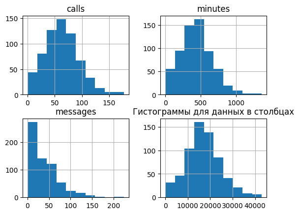

```
'-------------------------'
```

|  | calls | minutes | messages | mb_used |
| --- | --- | --- | --- | --- |
| calls | 1.000000 | 0.979700 | 0.205141 | 0.307184 |
| minutes | 0.979700 | 1.000000 | 0.206067 | 0.305625 |
| messages | 0.205141 | 0.206067 | 1.000000 | 0.136706 |
| mb_used | 0.307184 | 0.305625 | 0.136706 | 1.000000 |

```
'-------------------------'
```

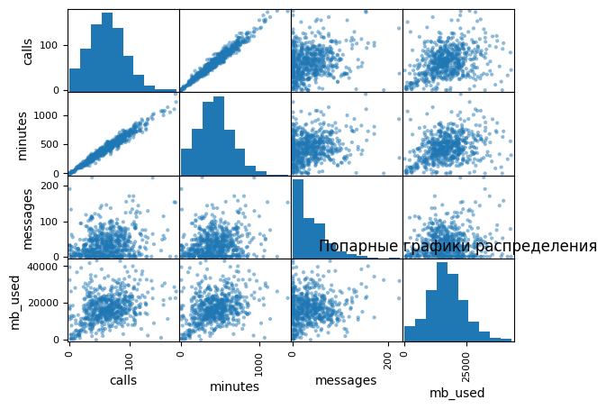

```
'-------------------------'
```

```
'Информация для колоки'
```

```
'calls'
```

```
count    643.000000
mean      63.116641
std       31.586361
min        0.000000
25%       40.000000
50%       62.000000
75%       82.000000
max      177.000000
Name: calls, dtype: float64
```

```
'-------------------------'
```

```
'calls'
```

```
array([  0.,   2.,   3.,   4.,   5.,   6.,   7.,   9.,  10.,  11.,  12.,
        13.,  14.,  15.,  16.,  17.,  18.,  19.,  20.,  21.,  22.,  23.,
        24.,  25.,  26.,  27.,  28.,  29.,  30.,  31.,  32.,  33.,  34.,
        35.,  36.,  37.,  38.,  39.,  40.,  41.,  42.,  43.,  44.,  45.,
        46.,  47.,  48.,  49.,  50.,  51.,  52.,  53.,  54.,  55.,  56.,
        57.,  58.,  59.,  60.,  61.,  62.,  63.,  64.,  65.,  66.,  67.,
        68.,  69.,  70.,  71.,  72.,  73.,  74.,  75.,  76.,  77.,  78.,
        79.,  80.,  81.,  82.,  83.,  84.,  85.,  86.,  87.,  88.,  89.,
        90.,  91.,  92.,  93.,  94.,  95.,  96.,  97.,  98.,  99., 100.,
       101., 102., 104., 105., 106., 107., 108., 109., 110., 111., 112.,
       114., 115., 116., 117., 118., 119., 120., 121., 125., 126., 127.,
       128., 129., 130., 136., 138., 140., 152., 154., 156., 158., 163.,
       167., 174., 176., 177.])
```

```
'calls'
```

```
': кол-во NaN'
```

```
0
```

```
', процент NaN'
```

```
0.0
```

```
'%'
```

```
'-------------------------'
```

```
'Информация для колоки'
```

```
'minutes'
```

```
count     643.000000
mean      438.327263
std       221.874251
min         0.000000
25%       286.175000
50%       429.330000
75%       565.175000
max      1364.830000
Name: minutes, dtype: float64
```

```
'-------------------------'
```

```
'minutes'
```

```
array([   0.  ,    1.99,    2.  ,    5.61,    6.42,    9.01,   14.04,
         19.85,   22.13,   22.96,   23.54,   29.31,   32.49,   35.43,
         35.47,   37.36,   46.76,   47.02,   58.87,   62.62,   64.66,
         68.41,   78.67,   80.8 ,   86.62,   92.38,   94.75,   96.36,
        100.66,  100.87,  101.54,  101.63,  104.41,  104.86,  105.48,
        107.25,  107.51,  110.29,  119.2 ,  119.61,  122.04,  122.87,
        127.62,  130.76,  130.88,  132.63,  133.41,  135.33,  136.48,
        145.13,  145.75,  146.74,  147.69,  148.36,  149.04,  152.39,
        153.  ,  154.46,  157.74,  159.55,  163.09,  163.17,  165.05,
        166.74,  168.44,  169.77,  171.55,  171.7 ,  172.08,  173.9 ,
        178.32,  178.82,  181.73,  182.51,  183.8 ,  185.18,  185.63,
        187.52,  188.44,  189.39,  191.44,  191.56,  200.94,  201.35,
        202.36,  202.91,  205.35,  205.6 ,  207.18,  208.48,  211.45,
        211.53,  213.05,  215.52,  220.24,  221.59,  223.97,  224.79,
        225.89,  226.  ,  226.06,  227.3 ,  227.67,  227.7 ,  229.15,
        229.49,  229.53,  230.99,  232.85,  232.86,  235.06,  236.38,
        237.73,  239.09,  241.75,  242.84,  244.43,  244.64,  245.55,
        246.06,  247.29,  247.63,  248.36,  249.5 ,  250.07,  250.3 ,
        253.36,  257.63,  258.7 ,  258.97,  259.07,  259.23,  261.68,
        262.26,  263.89,  264.76,  264.92,  265.04,  265.8 ,  266.45,
        266.46,  267.67,  268.84,  270.06,  274.53,  274.71,  275.74,
        275.75,  275.8 ,  276.97,  278.79,  280.7 ,  285.74,  285.77,
        285.92,  286.43,  286.68,  287.34,  291.52,  292.12,  293.54,
        294.96,  295.55,  296.26,  298.6 ,  298.79,  301.04,  301.49,
        301.58,  302.11,  302.61,  305.03,  305.21,  306.4 ,  307.95,
        308.  ,  308.23,  309.18,  312.02,  312.38,  312.8 ,  312.85,
        317.27,  319.8 ,  319.84,  320.13,  322.44,  323.62,  323.99,
        324.88,  328.73,  328.74,  329.1 ,  329.42,  329.61,  329.7 ,
        329.85,  330.75,  331.84,  331.98,  333.23,  333.36,  333.49,
        334.29,  336.13,  336.33,  336.38,  338.  ,  338.05,  338.52,
        338.6 ,  340.02,  340.04,  340.14,  341.14,  342.07,  344.32,
        344.56,  346.55,  346.88,  347.66,  348.02,  348.5 ,  350.72,
        352.46,  352.55,  353.2 ,  353.63,  354.91,  356.82,  357.02,
        357.58,  357.95,  359.52,  360.78,  360.87,  361.07,  362.64,
        362.87,  363.09,  363.42,  366.78,  368.87,  368.88,  368.96,
        369.4 ,  370.03,  371.86,  372.18,  372.34,  372.57,  375.3 ,
        376.67,  378.52,  379.73,  380.27,  381.49,  383.34,  383.97,
        385.09,  385.24,  385.45,  385.59,  385.72,  386.44,  386.74,
        387.05,  387.07,  388.1 ,  388.18,  390.62,  391.04,  391.22,
        392.47,  393.26,  394.88,  395.33,  395.71,  396.29,  396.41,
```

[output cut: 36 more lines]

```
        654.76,  654.92,  657.35,  658.24,  658.89,  664.48,  664.7 ,
        664.97,  666.29,  666.56,  667.18,  667.67,  669.06,  669.17,
        670.08,  678.61,  679.07,  679.61,  687.91,  687.92,  691.37,
        696.17,  699.74,  701.82,  702.47,  703.35,  703.76,  704.3 ,
        705.05,  705.6 ,  705.9 ,  707.16,  707.16,  707.37,  709.39,
        709.4 ,  709.48,  710.2 ,  714.18,  717.85,  719.51,  719.71,
        720.51,  721.82,  724.57,  728.68,  729.71,  731.07,  732.15,
        732.41,  732.81,  733.45,  737.27,  738.58,  739.27,  740.68,
        748.44,  751.82,  752.7 ,  754.05,  760.04,  760.64,  763.22,
        772.08,  773.59,  781.88,  789.17,  791.91,  793.69,  794.03,
        798.37,  802.98,  814.29,  820.07,  823.58,  831.37,  832.11,
        835.29,  844.52,  845.72,  848.44,  848.86,  848.92,  860.75,
        868.26,  872.52,  877.56,  901.84,  925.58,  932.14,  933.86,
        936.67,  965.78,  999.53, 1009.11, 1023.75, 1051.69, 1058.22,
       1067.24, 1078.64, 1078.86, 1104.73, 1139.13, 1228.53, 1364.83])
```

```
'minutes'
```

```
': кол-во NaN'
```

```
0
```

```
', процент NaN'
```

```
0.0
```

```
'%'
```

```
'-------------------------'
```

```
'Информация для колоки'
```

```
'messages'
```

```
count    643.000000
mean      37.594090
std       36.188522
min        0.000000
25%        9.000000
50%       30.000000
75%       56.000000
max      224.000000
Name: messages, dtype: float64
```

```
'-------------------------'
```

```
'messages'
```

```
array([  0.,   1.,   2.,   3.,   4.,   5.,   6.,   7.,   8.,   9.,  10.,
        11.,  12.,  13.,  14.,  15.,  16.,  17.,  18.,  19.,  20.,  21.,
        22.,  23.,  24.,  25.,  26.,  27.,  28.,  29.,  30.,  31.,  32.,
        33.,  34.,  35.,  36.,  37.,  38.,  39.,  40.,  41.,  42.,  43.,
        44.,  45.,  46.,  47.,  48.,  49.,  50.,  51.,  52.,  53.,  54.,
        55.,  56.,  57.,  58.,  59.,  60.,  61.,  62.,  63.,  64.,  65.,
        66.,  67.,  68.,  69.,  70.,  71.,  72.,  73.,  74.,  75.,  76.,
        77.,  78.,  79.,  80.,  81.,  82.,  83.,  84.,  85.,  86.,  88.,
        89.,  90.,  91.,  92.,  93.,  94.,  96.,  98.,  99., 101., 102.,
       103., 105., 107., 108., 109., 110., 112., 113., 114., 118., 121.,
       122., 124., 125., 128., 129., 133., 134., 137., 144., 146., 153.,
       154., 155., 158., 171., 191., 223., 224.])
```

```
'messages'
```

```
': кол-во NaN'
```

```
0
```

```
', процент NaN'
```

```
0.0
```

```
'%'
```

```
'-------------------------'
```

```
'Информация для колоки'
```

```
'mb_used'
```

```
count      643.000000
mean     17086.264401
std       7632.421480
min          0.000000
25%      12177.605000
50%      16617.790000
75%      21529.370000
max      42986.700000
Name: mb_used, dtype: float64
```

```
'-------------------------'
```

```
'mb_used'
```

```
array([    0.  ,   407.66,   478.96,   539.37,   616.65,   671.96,
         959.51,  1009.95,  1151.08,  1444.15,  2000.51,  2016.72,
        2123.81,  2147.25,  2299.74,  2335.64,  2451.9 ,  2696.04,
        2710.09,  2745.83,  2827.29,  2861.  ,  2866.41,  3139.82,
        3370.13,  3513.29,  3762.75,  3864.96,  4060.64,  4136.87,
        4208.92,  4294.  ,  4674.47,  4677.85,  4894.6 ,  4986.91,
        5134.01,  5157.33,  5177.62,  5181.6 ,  5200.13,  5426.77,
        5579.28,  5661.23,  5762.76,  5890.07,  5950.32,  6033.38,
        6037.69,  6195.54,  6547.66,  6928.  ,  7016.49,  7023.2 ,
        7076.63,  7122.54,  7325.36,  7357.66,  7414.17,  7455.94,
        7715.28,  7723.3 ,  7798.27,  7884.19,  7972.12,  7997.91,
        8003.98,  8017.23,  8069.96,  8177.23,  8228.28,  8252.13,
        8289.21,  8336.27,  8434.2 ,  8448.76,  8557.66,  8583.78,
        8622.56,  8643.29,  8644.66,  8657.77,  8778.89,  8787.01,
        8826.2 ,  8897.95,  9027.27,  9031.85,  9121.7 ,  9209.17,
        9376.42,  9388.43,  9460.28,  9465.94,  9536.33,  9607.85,
        9632.36,  9670.72,  9804.44,  9871.13,  9941.3 , 10032.39,
       10049.81, 10105.48, 10294.77, 10435.47, 10523.88, 10542.8 ,
       10590.07, 10603.12, 10624.74, 10683.75, 10756.78, 10891.23,
       10928.31, 10933.27, 10945.58, 10968.37, 11000.61, 11050.62,
       11109.03, 11136.1 , 11147.8 , 11191.22, 11204.59, 11236.66,
       11261.12, 11309.14, 11311.36, 11325.96, 11348.32, 11355.36,
       11407.52, 11420.07, 11428.54, 11430.52, 11437.89, 11446.02,
       11467.55, 11510.83, 11597.57, 11627.13, 11655.67, 11662.03,
       11684.21, 11770.17, 11774.26, 11793.47, 11816.92, 11859.17,
       11873.3 , 11919.35, 11925.48, 11957.52, 11967.96, 11968.22,
       12045.84, 12049.53, 12115.87, 12136.63, 12155.46, 12199.75,
       12311.24, 12398.26, 12403.15, 12406.  , 12411.02, 12450.24,
       12451.74, 12454.62, 12491.75, 12550.98, 12559.44, 12583.96,
       12633.89, 12643.05, 12706.94, 12723.52, 12755.7 , 12762.99,
       12774.8 , 12880.08, 12972.4 , 12991.39, 13026.1 , 13107.42,
       13114.53, 13121.85, 13158.94, 13197.15, 13217.21, 13222.54,
       13249.14, 13295.63, 13361.74, 13371.92, 13389.11, 13396.91,
       13469.35, 13497.97, 13559.68, 13581.94, 13615.57, 13618.46,
       13649.65, 13669.66, 13700.2 , 13716.  , 13752.2 , 13779.45,
       13843.33, 13850.84, 13866.31, 13888.33, 13889.73, 13893.98,
       13895.91, 13957.77, 13981.21, 13982.96, 14036.72, 14101.69,
       14138.49, 14153.7 , 14195.88, 14214.92, 14269.95, 14288.14,
       14325.37, 14340.84, 14344.72, 14359.01, 14368.42, 14370.82,
       14407.85, 14442.64, 14477.3 , 14487.66, 14491.72, 14550.67,
```

[output cut: 53 more lines]

```
       25013.18, 25160.62, 25208.92, 25494.78, 25521.07, 25739.  ,
       25740.71, 25803.71, 25811.64, 25950.28, 26231.2 , 26247.41,
       26395.12, 26423.48, 26517.44, 26607.42, 26934.77, 27138.53,
       27183.14, 27194.86, 27304.11, 27464.55, 27573.83, 27705.14,
       27762.85, 27802.78, 27807.13, 27935.42, 27967.26, 28029.08,
       28155.4 , 28183.29, 28224.16, 28356.32, 28477.99, 28489.81,
       28599.74, 28724.23, 28775.89, 28836.53, 28987.39, 29301.67,
       29335.15, 29374.16, 29488.01, 29555.11, 29652.09, 29738.88,
       30323.43, 30545.02, 30633.32, 30671.  , 30681.14, 30981.68,
       30996.3 , 31015.1 , 31845.11, 31942.4 , 31992.1 , 32448.02,
       32503.74, 32528.11, 32649.97, 32670.36, 32715.31, 33044.85,
       33272.81, 33526.69, 34297.22, 34506.26, 34556.2 , 35177.94,
       35497.91, 36628.85, 36878.02, 37165.83, 37383.2 , 38309.87,
       38999.59, 39419.77, 39597.61, 39930.07, 41587.07, 42735.18,
       42986.7 ])
```

```
'mb_used'
```

```
': кол-во NaN'
```

```
0
```

```
', процент NaN'
```

```
0.0
```

```
'%'
```

```python
data_frame_info(features_test)
```

```
'Количество явных дубликатов:'
```

```
0
```

```
'-------------------------'
```

```
<class 'pandas.core.frame.DataFrame'>
Int64Index: 643 entries, 272 to 2431
Data columns (total 4 columns):
 #   Column    Non-Null Count  Dtype
---  ------    --------------  -----
 0   calls     643 non-null    float64
 1   minutes   643 non-null    float64
 2   messages  643 non-null    float64
 3   mb_used   643 non-null    float64
dtypes: float64(4)
memory usage: 25.1 KB
```

```
None
```

```
'-------------------------'
```

```
array([[<AxesSubplot:title={'center':'calls'}>,
        <AxesSubplot:title={'center':'minutes'}>],
       [<AxesSubplot:title={'center':'messages'}>,
        <AxesSubplot:title={'center':'mb_used'}>]], dtype=object)
```

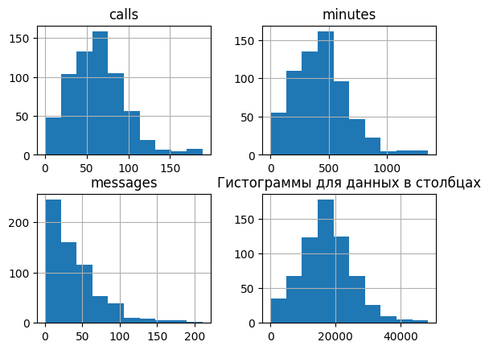

```
'-------------------------'
```

|  | calls | minutes | messages | mb_used |
| --- | --- | --- | --- | --- |
| calls | 1.000000 | 0.983452 | 0.208750 | 0.271584 |
| minutes | 0.983452 | 1.000000 | 0.197484 | 0.270729 |
| messages | 0.208750 | 0.197484 | 1.000000 | 0.229675 |
| mb_used | 0.271584 | 0.270729 | 0.229675 | 1.000000 |

```
'-------------------------'
```

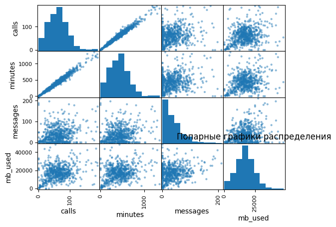

```
'-------------------------'
```

```
'Информация для колоки'
```

```
'calls'
```

```
count    643.000000
mean      62.391913
std       33.206970
min        0.000000
25%       39.000000
50%       61.000000
75%       81.000000
max      189.000000
Name: calls, dtype: float64
```

```
'-------------------------'
```

```
'calls'
```

```
array([  0.,   1.,   2.,   3.,   4.,   5.,   7.,   8.,   9.,  10.,  11.,
        13.,  14.,  15.,  16.,  17.,  18.,  19.,  20.,  21.,  22.,  23.,
        24.,  25.,  26.,  27.,  28.,  29.,  30.,  31.,  32.,  33.,  34.,
        35.,  36.,  37.,  38.,  39.,  40.,  41.,  42.,  43.,  44.,  45.,
        46.,  47.,  48.,  49.,  50.,  51.,  52.,  53.,  54.,  55.,  56.,
        57.,  58.,  59.,  60.,  61.,  62.,  63.,  64.,  65.,  66.,  67.,
        68.,  69.,  70.,  71.,  72.,  73.,  74.,  75.,  76.,  77.,  78.,
        79.,  80.,  81.,  82.,  83.,  84.,  85.,  86.,  87.,  88.,  89.,
        90.,  91.,  92.,  93.,  94.,  95.,  96.,  97.,  98.,  99., 100.,
       101., 102., 103., 104., 105., 106., 107., 109., 110., 111., 112.,
       114., 115., 116., 117., 118., 120., 122., 123., 125., 128., 132.,
       133., 134., 137., 143., 151., 152., 153., 156., 159., 169., 172.,
       173., 178., 182., 183., 184., 188., 189.])
```

```
'calls'
```

```
': кол-во NaN'
```

```
0
```

```
', процент NaN'
```

```
0.0
```

```
'%'
```

```
'-------------------------'
```

```
'Информация для колоки'
```

```
'minutes'
```

```
count     643.000000
mean      434.488865
std       235.558353
min         0.000000
25%       268.910000
50%       429.890000
75%       564.010000
max      1354.750000
Name: minutes, dtype: float64
```

```
'-------------------------'
```

```
'minutes'
```

```
array([0.00000e+00, 1.00000e+00, 1.37000e+00, 1.33900e+01, 1.42200e+01,
       1.62900e+01, 1.87300e+01, 1.93300e+01, 2.23100e+01, 2.35300e+01,
       2.85600e+01, 2.85900e+01, 3.29000e+01, 3.29200e+01, 3.93600e+01,
       4.02400e+01, 4.12700e+01, 4.33900e+01, 4.53800e+01, 4.99500e+01,
       6.18500e+01, 6.36500e+01, 7.05000e+01, 7.15300e+01, 7.78200e+01,
       7.79400e+01, 7.92600e+01, 8.13800e+01, 8.25500e+01, 8.95600e+01,
       9.18100e+01, 9.41900e+01, 9.49300e+01, 1.00790e+02, 1.02690e+02,
       1.02890e+02, 1.04020e+02, 1.04030e+02, 1.10900e+02, 1.12980e+02,
       1.18510e+02, 1.23750e+02, 1.28510e+02, 1.29010e+02, 1.30180e+02,
       1.31970e+02, 1.32400e+02, 1.34240e+02, 1.34710e+02, 1.35250e+02,
       1.36210e+02, 1.39270e+02, 1.39550e+02, 1.41050e+02, 1.41630e+02,
       1.41990e+02, 1.43870e+02, 1.45380e+02, 1.48630e+02, 1.50060e+02,
       1.51000e+02, 1.51720e+02, 1.52000e+02, 1.52900e+02, 1.55220e+02,
       1.57420e+02, 1.63100e+02, 1.69250e+02, 1.69930e+02, 1.70000e+02,
       1.70580e+02, 1.71550e+02, 1.71820e+02, 1.72100e+02, 1.75360e+02,
       1.75950e+02, 1.75960e+02, 1.77590e+02, 1.79470e+02, 1.80120e+02,
       1.82450e+02, 1.87370e+02, 1.89800e+02, 1.89960e+02, 1.90360e+02,
       1.91060e+02, 1.91510e+02, 1.92290e+02, 1.93570e+02, 1.93880e+02,
       1.98120e+02, 1.98500e+02, 1.99980e+02, 2.01370e+02, 2.03330e+02,
       2.04000e+02, 2.05770e+02, 2.06010e+02, 2.07050e+02, 2.08670e+02,
       2.10780e+02, 2.11060e+02, 2.12460e+02, 2.13760e+02, 2.14380e+02,
       2.15670e+02, 2.15890e+02, 2.17990e+02, 2.18950e+02, 2.19480e+02,
       2.23580e+02, 2.24390e+02, 2.25780e+02, 2.25970e+02, 2.26240e+02,
       2.26820e+02, 2.27410e+02, 2.27580e+02, 2.28070e+02, 2.29120e+02,
       2.32350e+02, 2.32800e+02, 2.34180e+02, 2.34200e+02, 2.34740e+02,
       2.38520e+02, 2.38700e+02, 2.39390e+02, 2.42620e+02, 2.43400e+02,
       2.43630e+02, 2.45640e+02, 2.46790e+02, 2.47690e+02, 2.50560e+02,
       2.50640e+02, 2.52050e+02, 2.55320e+02, 2.57090e+02, 2.57710e+02,
       2.57930e+02, 2.58090e+02, 2.58820e+02, 2.58930e+02, 2.59790e+02,
       2.62070e+02, 2.63170e+02, 2.63570e+02, 2.63640e+02, 2.65380e+02,
       2.65890e+02, 2.66140e+02, 2.67580e+02, 2.68500e+02, 2.68550e+02,
       2.68660e+02, 2.69160e+02, 2.69240e+02, 2.69320e+02, 2.69470e+02,
       2.71410e+02, 2.72850e+02, 2.72970e+02, 2.73400e+02, 2.73600e+02,
       2.74850e+02, 2.76800e+02, 2.76810e+02, 2.77790e+02, 2.77940e+02,
       2.78100e+02, 2.78270e+02, 2.79060e+02, 2.80330e+02, 2.82910e+02,
       2.83760e+02, 2.84060e+02, 2.84700e+02, 2.84870e+02, 2.85250e+02,
       2.86570e+02, 2.87690e+02, 2.87930e+02, 2.88430e+02, 2.89220e+02,
       2.89830e+02, 2.90200e+02, 2.90690e+02, 2.91420e+02, 2.92200e+02,
       2.93420e+02, 2.94370e+02, 2.97860e+02, 2.98420e+02, 2.98900e+02,
       3.00970e+02, 3.02430e+02, 3.03110e+02, 3.03760e+02, 3.04280e+02,
```

[output cut: 73 more lines]

```
       7.13440e+02, 7.16920e+02, 7.20600e+02, 7.25620e+02, 7.28170e+02,
       7.31920e+02, 7.32200e+02, 7.35900e+02, 7.39280e+02, 7.40280e+02,
       7.42650e+02, 7.43220e+02, 7.45000e+02, 7.45400e+02, 7.52200e+02,
       7.55420e+02, 7.55550e+02, 7.56620e+02, 7.58660e+02, 7.58980e+02,
       7.60530e+02, 7.63270e+02, 7.67580e+02, 7.68760e+02, 7.79500e+02,
       7.82500e+02, 7.83690e+02, 7.84470e+02, 7.95360e+02, 7.96790e+02,
       8.04840e+02, 8.09930e+02, 8.13660e+02, 8.14530e+02, 8.15020e+02,
       8.20970e+02, 8.21910e+02, 8.26130e+02, 8.34020e+02, 8.37760e+02,
       8.46570e+02, 8.54240e+02, 8.56900e+02, 8.58020e+02, 8.66870e+02,
       8.79520e+02, 8.81060e+02, 8.96240e+02, 8.99900e+02, 9.05060e+02,
       9.10980e+02, 9.32680e+02, 9.40770e+02, 9.47710e+02, 9.72700e+02,
       1.01244e+03, 1.01719e+03, 1.02937e+03, 1.04897e+03, 1.11151e+03,
       1.15453e+03, 1.16512e+03, 1.17060e+03, 1.18818e+03, 1.20311e+03,
       1.22519e+03, 1.24704e+03, 1.25532e+03, 1.29022e+03, 1.30289e+03,
       1.35475e+03])
```

```
'minutes'
```

```
': кол-во NaN'
```

```
0
```

```
', процент NaN'
```

```
0.0
```

```
'%'
```

```
'-------------------------'
```

```
'Информация для колоки'
```

```
'messages'
```

```
count    643.000000
mean      38.209953
std       36.246058
min        0.000000
25%       10.000000
50%       30.000000
75%       55.000000
max      211.000000
Name: messages, dtype: float64
```

```
'-------------------------'
```

```
'messages'
```

```
array([  0.,   1.,   2.,   3.,   4.,   5.,   6.,   7.,   8.,   9.,  10.,
        11.,  12.,  13.,  14.,  15.,  16.,  17.,  18.,  19.,  20.,  21.,
        22.,  23.,  24.,  25.,  26.,  27.,  28.,  29.,  30.,  31.,  32.,
        33.,  34.,  35.,  36.,  37.,  38.,  39.,  40.,  41.,  42.,  43.,
        44.,  45.,  46.,  47.,  48.,  49.,  50.,  51.,  52.,  53.,  54.,
        55.,  56.,  57.,  58.,  59.,  60.,  61.,  62.,  63.,  64.,  65.,
        66.,  67.,  68.,  69.,  71.,  72.,  73.,  74.,  75.,  76.,  77.,
        78.,  79.,  80.,  81.,  82.,  83.,  84.,  85.,  86.,  87.,  88.,
        89.,  90.,  91.,  93.,  94.,  96.,  97.,  98.,  99., 101., 103.,
       104., 105., 106., 107., 108., 109., 111., 113., 115., 117., 126.,
       129., 137., 139., 140., 141., 143., 145., 148., 150., 151., 157.,
       159., 172., 178., 180., 183., 188., 197., 211.])
```

```
'messages'
```

```
': кол-во NaN'
```

```
0
```

```
', процент NaN'
```

```
0.0
```

```
'%'
```

```
'-------------------------'
```

```
'Информация для колоки'
```

```
'mb_used'
```

```
count      643.000000
mean     17299.039798
std       7875.401202
min          0.000000
25%      12385.460000
50%      16805.650000
75%      21689.900000
max      48351.610000
Name: mb_used, dtype: float64
```

```
'-------------------------'
```

```
'mb_used'
```

```
array([    0.  ,   201.08,   588.89,   669.77,  1160.41,  1175.75,
        1392.19,  1619.61,  1981.69,  2042.74,  2243.66,  2289.7 ,
        2292.07,  2412.34,  2538.67,  2727.97,  2743.76,  2890.46,
        2921.57,  3082.69,  3170.83,  3275.61,  3315.76,  3370.69,
        3431.02,  3694.87,  3738.9 ,  4134.29,  4159.19,  4383.9 ,
        4436.91,  4719.69,  4817.  ,  4880.62,  4926.14,  5024.19,
        5144.73,  5185.2 ,  5336.82,  5451.26,  5529.38,  5813.08,
        5910.35,  5957.73,  6040.48,  6266.27,  6294.31,  6348.47,
        6444.32,  6557.41,  6561.24,  6572.61,  6618.91,  6674.71,
        6782.84,  6967.  ,  7093.61,  7154.59,  7350.17,  7383.95,
        7476.26,  7512.26,  7538.76,  7543.67,  7653.43,  7694.58,
        7716.72,  7865.58,  7939.29,  7957.08,  8022.79,  8152.11,
        8209.15,  8246.64,  8309.98,  8327.46,  8413.88,  8449.53,
        8503.11,  8507.87,  8540.27,  8616.96,  8668.24,  8674.38,
        8678.32,  8700.81,  8739.55,  8761.02,  8799.48,  8853.22,
        8859.08,  8922.77,  8946.73,  8977.45,  9080.99,  9183.85,
        9192.92,  9308.63,  9346.  ,  9507.71,  9667.4 ,  9793.43,
        9850.74,  9892.16,  9958.5 ,  9988.18, 10015.52, 10051.92,
       10143.2 , 10174.47, 10272.33, 10277.91, 10289.26, 10375.99,
       10411.44, 10418.99, 10574.2 , 10594.24, 10621.59, 10648.36,
       10678.96, 10781.76, 10806.69, 10845.54, 10944.14, 11141.11,
       11166.22, 11178.07, 11189.95, 11230.93, 11265.49, 11284.14,
       11290.13, 11308.65, 11310.87, 11311.21, 11337.85, 11348.42,
       11379.32, 11382.98, 11412.69, 11425.27, 11441.18, 11500.29,
       11562.48, 11584.49, 11608.63, 11640.09, 11687.05, 11787.3 ,
       11824.8 , 11990.31, 12003.47, 12099.97, 12150.72, 12196.55,
       12272.83, 12279.31, 12327.99, 12442.93, 12445.61, 12458.34,
       12466.55, 12492.36, 12494.21, 12517.73, 12521.55, 12624.8 ,
       12673.71, 12737.08, 12750.82, 12840.4 , 12851.66, 12935.77,
       12942.02, 13013.33, 13052.67, 13105.3 , 13180.37, 13211.82,
       13246.51, 13291.98, 13432.3 , 13463.84, 13526.61, 13546.99,
       13643.08, 13654.59, 13662.74, 13666.81, 13681.41, 13684.88,
       13741.1 , 13772.98, 13846.03, 13863.77, 13872.16, 13941.6 ,
       13950.92, 13965.71, 13973.08, 13996.26, 13996.76, 14005.92,
       14035.87, 14037.9 , 14055.95, 14105.03, 14117.53, 14152.16,
       14156.14, 14170.07, 14174.84, 14199.01, 14256.68, 14259.08,
       14303.32, 14345.74, 14379.16, 14427.4 , 14439.86, 14463.84,
       14472.76, 14474.71, 14502.75, 14518.03, 14525.26, 14525.92,
       14556.84, 14568.93, 14589.41, 14620.28, 14620.52, 14706.16,
       14709.32, 14733.17, 14751.26, 14771.91, 14791.39, 14802.42,
```

[output cut: 52 more lines]

```
       25562.28, 25587.59, 25598.87, 25839.  , 25867.43, 25872.85,
       25994.12, 26019.3 , 26025.6 , 26095.  , 26154.33, 26186.6 ,
       26253.89, 26271.47, 26403.93, 26656.24, 26672.13, 26720.17,
       26756.07, 26802.84, 26965.37, 27093.07, 27144.87, 27198.91,
       27233.53, 27244.82, 27549.18, 27695.86, 27728.78, 27738.28,
       27782.77, 27823.72, 27950.85, 28002.44, 28042.76, 28187.72,
       28260.11, 28289.6 , 28294.62, 28395.82, 28584.39, 28639.49,
       28647.83, 28652.06, 29139.66, 29186.41, 29263.64, 29316.54,
       29361.18, 29460.56, 29480.52, 29942.59, 30135.27, 30307.39,
       30343.76, 30357.44, 30417.27, 30466.84, 30550.3 , 30558.11,
       31077.59, 31194.31, 31239.78, 32045.73, 32050.45, 32740.5 ,
       32950.36, 33189.5 , 33233.63, 33383.27, 33988.9 , 34224.57,
       34329.08, 35033.6 , 35124.9 , 35343.15, 36180.51, 36298.13,
       37075.18, 38552.62, 38798.13, 39195.64, 42144.5 , 42250.7 ,
       42320.89, 43574.64, 43931.39, 45180.75, 48351.61])
```

```
'mb_used'
```

```
': кол-во NaN'
```

```
0
```

```
', процент NaN'
```

```
0.0
```

```
'%'
```

```python
data_frame_info(features_valid)
```

```
'Количество явных дубликатов:'
```

```
0
```

```
'-------------------------'
```

```
<class 'pandas.core.frame.DataFrame'>
Int64Index: 1928 entries, 1890 to 1345
Data columns (total 4 columns):
 #   Column    Non-Null Count  Dtype
---  ------    --------------  -----
 0   calls     1928 non-null   float64
 1   minutes   1928 non-null   float64
 2   messages  1928 non-null   float64
 3   mb_used   1928 non-null   float64
dtypes: float64(4)
memory usage: 75.3 KB
```

```
None
```

```
'-------------------------'
```

```
array([[<AxesSubplot:title={'center':'calls'}>,
        <AxesSubplot:title={'center':'minutes'}>],
       [<AxesSubplot:title={'center':'messages'}>,
        <AxesSubplot:title={'center':'mb_used'}>]], dtype=object)
```

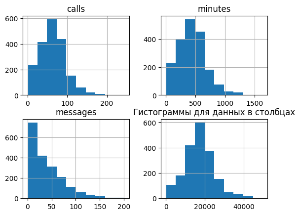

```
'-------------------------'
```

|  | calls | minutes | messages | mb_used |
| --- | --- | --- | --- | --- |
| calls | 1.000000 | 0.982339 | 0.158512 | 0.285485 |
| minutes | 0.982339 | 1.000000 | 0.154916 | 0.277182 |
| messages | 0.158512 | 0.154916 | 1.000000 | 0.203901 |
| mb_used | 0.285485 | 0.277182 | 0.203901 | 1.000000 |

```
'-------------------------'
```

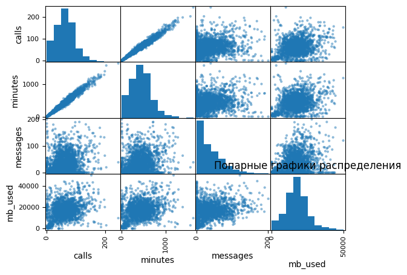

```
'-------------------------'
```

```
'Информация для колоки'
```

```
'calls'
```

```
count    1928.000000
mean       63.228734
std        33.792155
min         0.000000
25%        40.000000
50%        63.000000
75%        83.000000
max       244.000000
Name: calls, dtype: float64
```

```
'-------------------------'
```

```
'calls'
```

```
array([  0.,   1.,   2.,   3.,   4.,   5.,   6.,   7.,   8.,   9.,  10.,
        11.,  12.,  13.,  14.,  15.,  16.,  17.,  18.,  19.,  20.,  21.,
        22.,  23.,  24.,  25.,  26.,  27.,  28.,  29.,  30.,  31.,  32.,
        33.,  34.,  35.,  36.,  37.,  38.,  39.,  40.,  41.,  42.,  43.,
        44.,  45.,  46.,  47.,  48.,  49.,  50.,  51.,  52.,  53.,  54.,
        55.,  56.,  57.,  58.,  59.,  60.,  61.,  62.,  63.,  64.,  65.,
        66.,  67.,  68.,  69.,  70.,  71.,  72.,  73.,  74.,  75.,  76.,
        77.,  78.,  79.,  80.,  81.,  82.,  83.,  84.,  85.,  86.,  87.,
        88.,  89.,  90.,  91.,  92.,  93.,  94.,  95.,  96.,  97.,  98.,
        99., 100., 101., 102., 103., 104., 105., 106., 107., 108., 109.,
       110., 111., 112., 113., 114., 115., 116., 117., 118., 119., 120.,
       121., 122., 123., 124., 125., 126., 127., 128., 129., 130., 131.,
       133., 134., 136., 137., 138., 140., 141., 142., 143., 144., 145.,
       146., 148., 150., 152., 153., 155., 156., 157., 158., 159., 160.,
       161., 162., 164., 165., 168., 171., 176., 180., 181., 184., 185.,
       196., 198., 203., 244.])
```

```
'calls'
```

```
': кол-во NaN'
```

```
0
```

```
', процент NaN'
```

```
0.0
```

```
'%'
```

```
'-------------------------'
```

```
'Информация для колоки'
```

```
'minutes'
```

```
count    1928.000000
mean      439.409891
std       238.432076
min         0.000000
25%       274.377500
50%       431.905000
75%       578.802500
max      1632.060000
Name: minutes, dtype: float64
```

```
'-------------------------'
```

```
'minutes'
```

```
array([0.00000e+00, 1.00000e-01, 1.00000e+00, ..., 1.39022e+03,
       1.56645e+03, 1.63206e+03])
```

```
'minutes'
```

```
': кол-во NaN'
```

```
0
```

```
', процент NaN'
```

```
0.0
```

```
'%'
```

```
'-------------------------'
```

```
'Информация для колоки'
```

```
'messages'
```

```
count    1928.000000
mean       38.534232
std        36.117979
min         0.000000
25%         9.000000
50%        30.000000
75%        58.000000
max       201.000000
Name: messages, dtype: float64
```

```
'-------------------------'
```

```
'messages'
```

```
array([  0.,   1.,   2.,   3.,   4.,   5.,   6.,   7.,   8.,   9.,  10.,
        11.,  12.,  13.,  14.,  15.,  16.,  17.,  18.,  19.,  20.,  21.,
        22.,  23.,  24.,  25.,  26.,  27.,  28.,  29.,  30.,  31.,  32.,
        33.,  34.,  35.,  36.,  37.,  38.,  39.,  40.,  41.,  42.,  43.,
        44.,  45.,  46.,  47.,  48.,  49.,  50.,  51.,  52.,  53.,  54.,
        55.,  56.,  57.,  58.,  59.,  60.,  61.,  62.,  63.,  64.,  65.,
        66.,  67.,  68.,  69.,  70.,  71.,  72.,  73.,  74.,  75.,  76.,
        77.,  78.,  79.,  80.,  81.,  82.,  83.,  84.,  85.,  86.,  87.,
        88.,  89.,  90.,  91.,  92.,  93.,  94.,  95.,  96.,  97.,  98.,
        99., 100., 101., 102., 103., 104., 105., 106., 107., 108., 109.,
       111., 112., 113., 115., 116., 117., 118., 119., 120., 121., 123.,
       124., 126., 127., 128., 129., 130., 131., 132., 133., 134., 135.,
       136., 137., 138., 139., 140., 141., 142., 143., 145., 146., 148.,
       149., 152., 153., 154., 155., 157., 158., 162., 165., 169., 170.,
       171., 173., 176., 181., 182., 185., 190., 191., 201.])
```

```
'messages'
```

```
': кол-во NaN'
```

```
0
```

```
', процент NaN'
```

```
0.0
```

```
'%'
```

```
'-------------------------'
```

```
'Информация для колоки'
```

```
'mb_used'
```

```
count     1928.000000
mean     17217.693522
std       7449.384403
min          0.000000
25%      12662.855000
50%      17048.290000
75%      21291.630000
max      49745.730000
Name: mb_used, dtype: float64
```

```
'-------------------------'
```

```
'mb_used'
```

```
array([0.000000e+00, 1.000000e-02, 3.650900e+02, ..., 4.382493e+04,
       4.429686e+04, 4.974573e+04])
```

```
'mb_used'
```

```
': кол-во NaN'
```

```
0
```

```
', процент NaN'
```

```
0.0
```

```
'%'
```

```python
data_frame_info(features_train)
```

```python
target_test.describe()
```

```
count    643.000000
mean       0.306376
std        0.461347
min        0.000000
25%        0.000000
50%        0.000000
75%        1.000000
max        1.000000
Name: is_ultra, dtype: float64
```

```python
target_valid.describe()
```

```
count    643.000000
mean       0.306376
std        0.461347
min        0.000000
25%        0.000000
50%        0.000000
75%        1.000000
max        1.000000
Name: is_ultra, dtype: float64
```

```python
target_train.describe()
```

```
count    1928.000000
mean        0.306535
std         0.461174
min         0.000000
25%         0.000000
50%         0.000000
75%         1.000000
max         1.000000
Name: is_ultra, dtype: float64
```

**Предложение** Нарисовать ящики с усами для каждого из столбцов и каждой выборки + генеральный набор. 1 столбец 4 графика.

## Исследуйте модели

### Метрика

Для исследования мы должны выбрать метрику или метрики, которые будет определять качество модели.

#### Accuracy

В этом исследовании главной метрикой будет **accuracy**, которая определяет долю правильных ответов модели среди всех ответов на проверочном или тестовом заданиях.

#### Время исполнения (`execution_time`)

**Время выполнения** будет второй по значимости метрикой. Мы будем собирать данные по ней не тренировочной выборке, так как она занимает 60% всех данных.

### Классификатор дерева решений

#### Настройки по умолчанию

Обучим первую модель Дерева Решений с единственным гиперпараметром не установленным по умолчанию `random_state`.

```python
model = DecisionTreeClassifier(random_state=rs)
model.fit(features_train, target_train)
```

```
DecisionTreeClassifier(random_state=54321)
```

Сделаем предсказания на проверочной выборке и измерим долю правильных ответов `accuracity`. Не забывая, что наш ориентир- это больше 0,75.

```python
predictions = model.predict(features_valid)
accuracy_score(target_valid, predictions)
```

```
0.7293934681181959
```

**Вывод**: К сожалению, мы не достигли заданного ориентира на настройках по умолчанию.

#### Улучшение модели: глубина дерева решений

Для улучшения мы будем подбирать гиперпараметр **глубина дерева**.

Проверим модели с максимальной глубиной до 20.

И зафиксируем наши метрики `accuracity` и `execution_time` для каждой полученной модели.

Не будем забывать, что мы стремимся с показателям `accuracity` большим 0,75.

```python
# создадим датафрейм для записи наших наблюдений
stat_decision_tree = pd.DataFrame(columns=['depth', 'accuracy_train', 'accuracy_valid', 'execution_time_train'])

for depth in range(1, 21):
    model = DecisionTreeClassifier(max_depth=depth, random_state=rs) # задаем параметры модели
    # обучаем модель
    model.fit(features_train, target_train)
#    display( model.score(features_train, target_train))
    # собираем данные для execution_time
    start = time.time()
    predictions_train = model.predict(features_train)
    finish = time.time()
#    display( start, finish)
    execution_time = (float(finish) - float(start)) * 1000000
    # записываем данные в датафрейм
    stat_decision_tree = stat_decision_tree.append({'depth': depth
                                                    , 'accuracy_train': model.score(features_train, target_train)
                                                    , 'accuracy_valid': model.score(features_valid, target_valid)
                                                    , 'execution_time_train': execution_time
                                                   }
                                                    , ignore_index=True)
# выводим собранные данные
stat_decision_tree.sort_values(by='accuracy_valid', ascending=False)
```

|  | depth | accuracy_train | accuracy_valid | execution_time_train |
| --- | --- | --- | --- | --- |
| 6 | 7.0 | 0.844398 | 0.791602 | 7001.399994 |
| 2 | 3.0 | 0.799793 | 0.790047 | 6997.585297 |
| 3 | 4.0 | 0.809647 | 0.790047 | 8983.850479 |
| 7 | 8.0 | 0.854772 | 0.790047 | 6996.870041 |
| 8 | 9.0 | 0.869295 | 0.785381 | 5996.942520 |
| 1 | 2.0 | 0.780602 | 0.785381 | 3995.180130 |
| 5 | 6.0 | 0.830394 | 0.783826 | 2998.590469 |
| 10 | 11.0 | 0.899378 | 0.780715 | 2000.570297 |
| 4 | 5.0 | 0.814834 | 0.777605 | 5992.650986 |
| 12 | 13.0 | 0.932054 | 0.772939 | 4997.968674 |
| 9 | 10.0 | 0.884336 | 0.772939 | 4996.538162 |
| 11 | 12.0 | 0.913900 | 0.762053 | 2996.444702 |
| 0 | 1.0 | 0.748963 | 0.749611 | 2997.875214 |
| 13 | 14.0 | 0.947095 | 0.744946 | 3997.802734 |
| 14 | 15.0 | 0.960062 | 0.743390 | 2997.636795 |
| 16 | 17.0 | 0.981328 | 0.740280 | 2998.352051 |
| 17 | 18.0 | 0.992220 | 0.730949 | 3000.736237 |
| 15 | 16.0 | 0.975104 | 0.726283 | 3999.471664 |
| 19 | 20.0 | 0.997925 | 0.724728 | 3000.020981 |
| 18 | 19.0 | 0.995851 | 0.723173 | 1999.378204 |

Построим графики для наглядности.

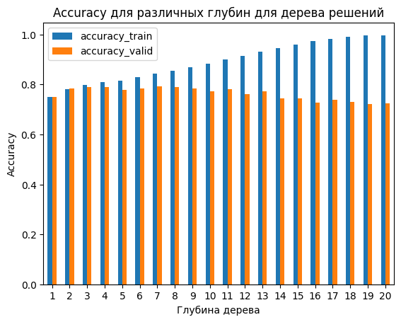

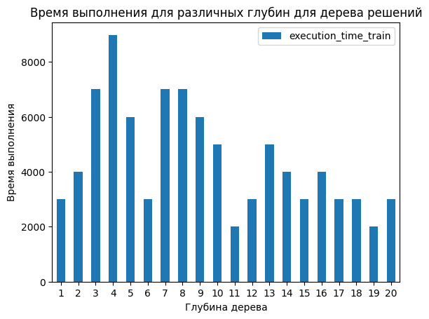

```python
# изменим тип данных для столбца depth
stat_decision_tree['depth'] = stat_decision_tree['depth'].astype('int')
# stat_decision_tree.info()
# график для Accuracy
stat_decision_tree.plot(x='depth'
                        , rot=0
                        , xlabel = 'Глубина дерева'
                        , y =['accuracy_train', 'accuracy_valid']
                        , ylabel = 'Accuracy'
                        , kind='bar'
                        , title='Accuracy для различных глубин для дерева решений'
                       )
plt.show()
# график для времени выполнения
stat_decision_tree.plot(x='depth'
                        , rot=0
                        , xlabel = 'Глубина дерева'
                        , y =['execution_time_train']
                        , ylabel = 'Время выполнения'
                        , kind='bar'
                        , title='Время выполнения для различных глубин для дерева решений'
                       )
plt.show()
```

#### Чемпионы из Деревьев Решений.

Запишем выбранную модель. И зафиксируем её результат *accuracy*.

```python
model_decision_tree_depth_3 = DecisionTreeClassifier(max_depth=3, random_state=rs)
model_decision_tree_depth_3.fit(features_train, target_train)
model_decision_tree_depth_3.score(features_valid, target_valid)
```

```
0.7900466562986003
```

**Дополнительно** Рассмотрим нашего чемпиона. Очень интересно как принимается решение.

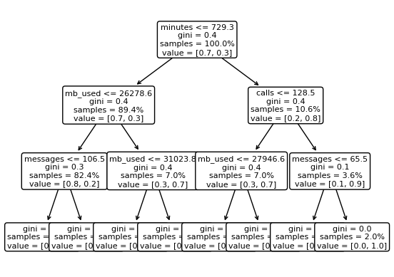

```python
plot_tree(model_decision_tree_depth_3, fontsize=8,
         feature_names=['calls', 'minutes', 'messages', 'mb_used'],
         proportion=True, rounded=True, precision=1)

plt.show()
```

### Классификатор случайный лес

#### Настройки по умолчанию

Обучим первую модель Случайного Леса с единственным гиперпараметром не установленным по умолчанию `random_state`.

```python
model = RandomForestClassifier(random_state=rs)
model.fit(features_train, target_train)
```

```
RandomForestClassifier(random_state=54321)
```

Сделаем предсказания на проверочной выборке и измерим долю правильных ответов `accuracity`. Не забывая, что наш ориентир- это больше 0,75.

```python
predictions = model.predict(features_valid)
accuracy_score(target_valid, predictions)
```

```
0.8009331259720062
```

**Вывод**: Сразу видно "один в поле не воин". Много деревьев- лучше результат. Мы достигли заданного ориентира на настройках по умолчанию. Но давайте все-равно попробуем улучшить модель не по глубине дерева, так по их каличеству. А так же зафиксируем параметры.

#### Улучшение модели: количество деревьев и их глубина.

Для увеличения `accuracy` мы будем работать с 2 гиперпараметрами:

- количеством деревьев, `n_estimators`,
- глубина деревьев, `max_depth`.

Каждый из параметров возьмем от 1 до 20.

Накопим данные по нашим метрикам и сделаем анализ, для выбора лучшей или лучших моделей.

Одной из метрик будет *время выполнения*, но как мы видели выше этот параметр может зависить от состояния аппаратной части. Поэтому мы логически предоположим, что чем меньшь количество деревье и их глубина/высота, тем быстрее наша модель может работать.

Так же мы будем активно убирать модели, где `accuracy` будет меньше 0,75 на тренировочной и проверочной выборках.

```python
%%time

stat_random_forest = pd.DataFrame(columns=['n_estimators', 'depth', 'accuracy_train', 'accuracy_valid', 'execution_time_train'])

for est in range(1, 21):
    for depth in range(1, 21):
        model = RandomForestClassifier(random_state=rs, n_estimators=est, max_depth=depth) # обучите модель с заданным количеством деревьев
        model.fit(features_train, target_train) # обучите модель на тренировочной выборке
        # собираем данные для execution_time
        start = time.time()
        predictions_train = model.predict(features_train)
        finish = time.time()
        execution_time = (float(finish) - float(start)) * 1000000
        # собираем данные
        stat_random_forest = stat_random_forest.append({'depth': depth
                                                        , 'n_estimators': est
                                                    , 'accuracy_train': model.score(features_train, target_train)
                                                    , 'accuracy_valid': model.score(features_valid, target_valid)
                                                    , 'execution_time_train': execution_time
                                                   }
                                                    , ignore_index=True)


stat_random_forest
```

```
Wall time: 25.5 s
```

|  | n_estimators | depth | accuracy_train | accuracy_valid | execution_time_train |
| --- | --- | --- | --- | --- | --- |
| 0 | 1.0 | 1.0 | 0.747925 | 0.757387 | 11006.593704 |
| 1 | 1.0 | 2.0 | 0.777490 | 0.769829 | 2998.828888 |
| 2 | 1.0 | 3.0 | 0.765041 | 0.738725 | 2996.206284 |
| 3 | 1.0 | 4.0 | 0.776971 | 0.776050 | 4997.253418 |
| 4 | 1.0 | 5.0 | 0.810166 | 0.786936 | 2999.305725 |
| ... | ... | ... | ... | ... | ... |
| 395 | 20.0 | 16.0 | 0.974585 | 0.804044 | 6508.350372 |
| 396 | 20.0 | 17.0 | 0.982884 | 0.786936 | 10073.900223 |
| 397 | 20.0 | 18.0 | 0.986515 | 0.790047 | 10073.184967 |
| 398 | 20.0 | 19.0 | 0.989108 | 0.790047 | 10096.788406 |
| 399 | 20.0 | 20.0 | 0.991183 | 0.791602 | 18111.705780 |

400 rows × 5 columns

Для наглядности нарисуем графики.

Уберем все значения, где `accurecy`, меньше 0,75.

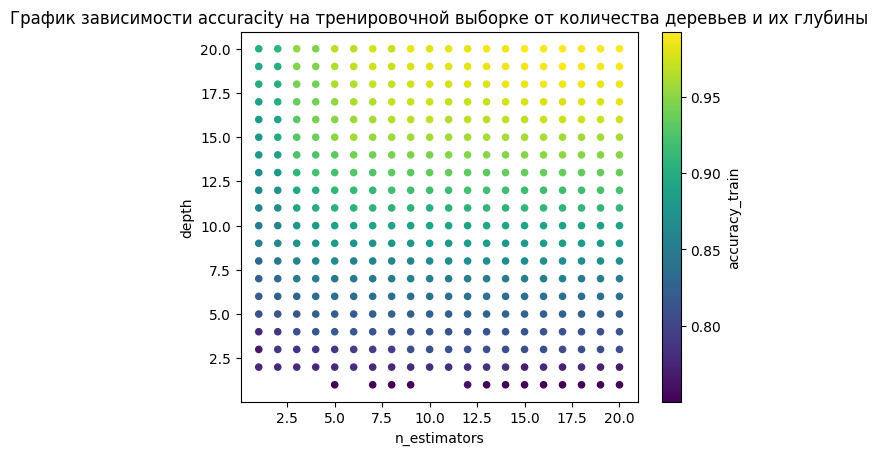

```python
stat_random_forest[stat_random_forest['accuracy_train'] > 0.75].plot.scatter(x='n_estimators'
                              , y='depth'
                              , title='График зависимости accuracity на тренировочной выборке от количества деревьев и их глубины'
                              , c='accuracy_train'
                              , colormap='viridis'
                             )
plt.show()
```

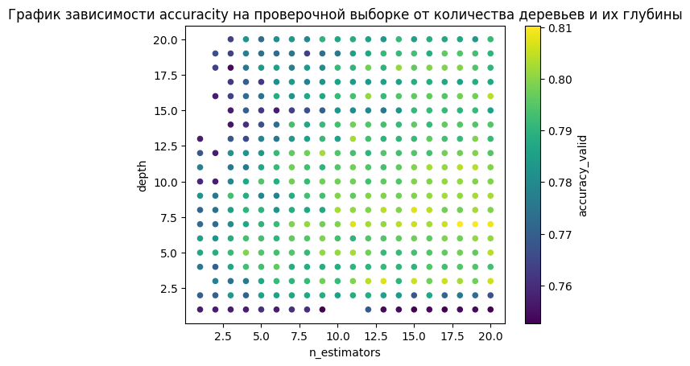

```python
stat_random_forest[stat_random_forest['accuracy_valid'] > 0.75].plot.scatter(x='n_estimators'
                              , y='depth'
                              , c='accuracy_valid'
                              , title='График зависимости accuracity на проверочной выборке от количества деревьев и их глубины'
                              , colormap='viridis'
                             )
plt.show()
```

На проверочной выборке есть модели с `accuracy` меньше 0,75 (мы убрали эти значения).

**Справочно**, построим график времени выполнения. Но, к сожалению, он меняется при различных состояниях аппаратной части при работе моделей.

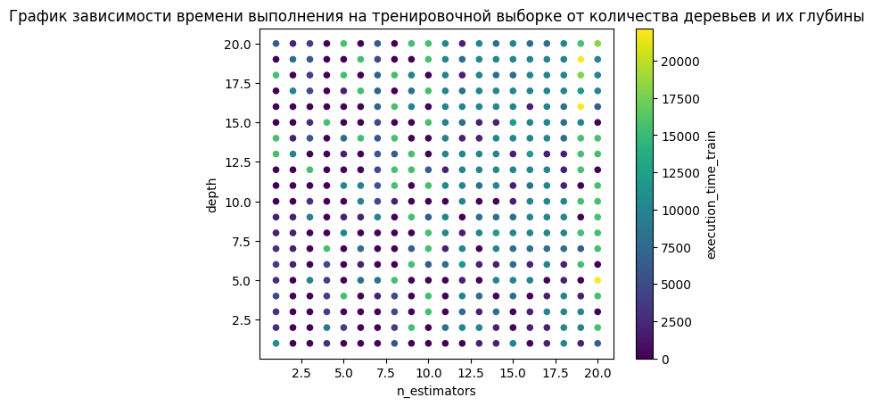

```python
stat_random_forest.plot.scatter(x='n_estimators'
                              , y='depth'
                              , c='execution_time_train'
                            , title='График зависимости времени выполнения на тренировочной выборке от количества деревьев и их глубины'
                              , colormap='viridis'
                             )
plt.show()
```

И **дополнительно** построим еще один график по всем параметрам с общей осью из параметров `n_estimators` и `depth`, тоесть количество деревьев и их глубина/высота.

Что интересно, на этом графике можно увидеть некоторые тенденции по метрике *время выполненни*. Скорее всего это связано с увеличение количества вычислений с ростом количества деревьев и их глубин/высоты.

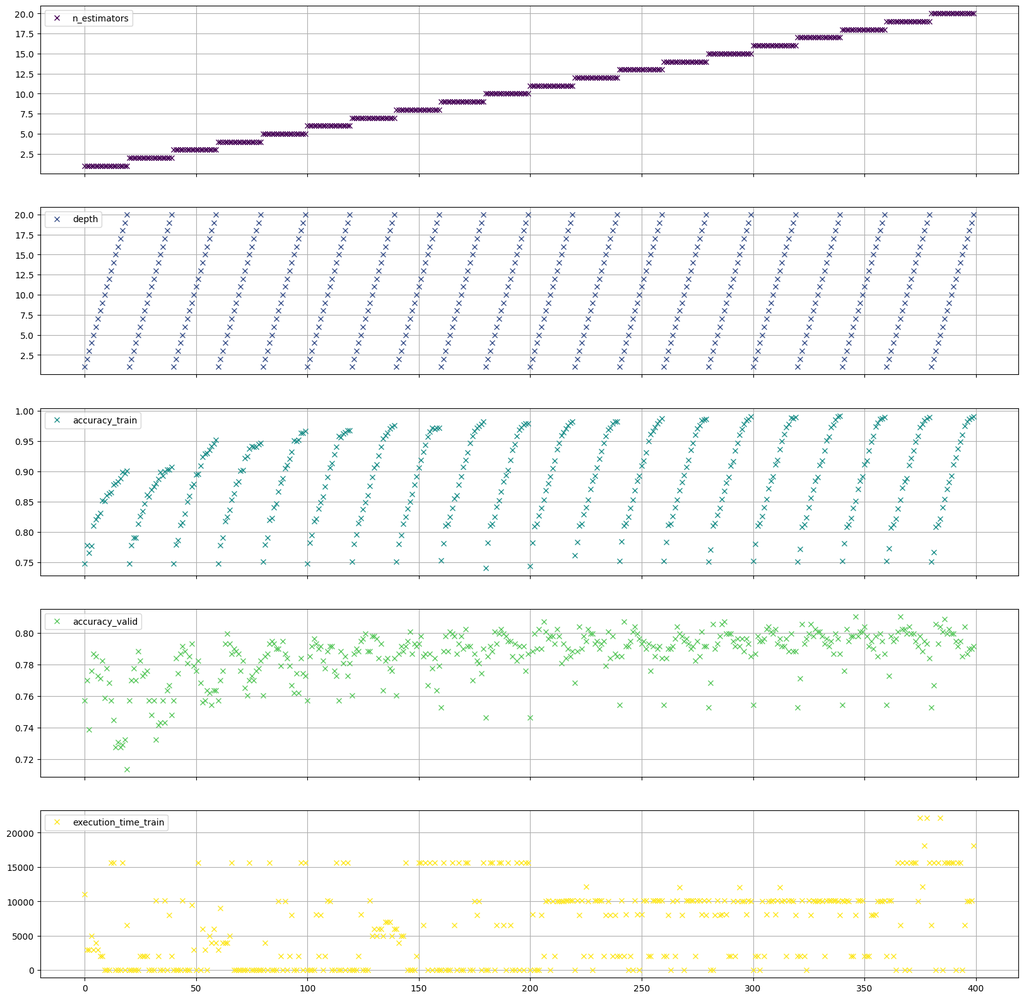

```python
stat_random_forest.plot(
    # x='n_estimators'
#                              , y='depth'
#                        , secondary_y='n_estimators'
#                              , c='accuracy_valid'
                          subplots=[('n_estimators', 'depth')]
#                              , title='График зависимости accuracity на проверочной выборке от количества деревьев и их глубины'
                              , colormap='viridis'
                        , grid=True
                        , style='x'
#                        , kind='bar'
                        , figsize=(20, 20)
                             )
plt.show()
```

Посмотрим подробнее и **выбреем модель, которая будет оптимизирована по времени выполнения и accuracy**.

Добавим в нашу таблицу столбец с произведения `n_estimators` * `depth`, как дополнительную оценку времени выполнения.

```python
stat_random_forest['mult_e_depth'] = stat_random_forest['n_estimators'] * stat_random_forest['depth']
```

Добавим в наши таблицу столбцы с суммой `accuracy_train` + `accuracy_valid`, как дополнительный параметр для оценки.

```python
stat_random_forest['sum_accuracy'] = stat_random_forest['accuracy_train'] + stat_random_forest['accuracy_valid']
```

Посмотрим, кто самый умный из быстрых.

Дополнительно:

- в лесу более 2 деревьев,
- все `accurecy` больше 0,75.

Сделаем сортировку для поиска максимального *accuracy_valid*.

```python
stat_random_forest.query('accuracy_train > 0.75 and accuracy_valid > 0.75 and n_estimators > 2')\
                    .sort_values(by='accuracy_valid', ascending=False)\
                    .head(10)
```

|  | n_estimators | depth | accuracy_train | accuracy_valid | execution_time_train | mult_e_depth | sum_accuracy |
| --- | --- | --- | --- | --- | --- | --- | --- |
| 346 | 18.0 | 7.0 | 0.850622 | 0.810264 | 8051.872253 | 126.0 | 1.660887 |
| 366 | 19.0 | 7.0 | 0.853216 | 0.810264 | 6508.827209 | 133.0 | 1.663480 |
| 386 | 20.0 | 7.0 | 0.853734 | 0.808709 | 15621.423721 | 140.0 | 1.662444 |
| 206 | 11.0 | 7.0 | 0.853216 | 0.807154 | 2011.299133 | 77.0 | 1.660370 |
| 287 | 15.0 | 8.0 | 0.867739 | 0.807154 | 10104.417801 | 120.0 | 1.674893 |
| 242 | 13.0 | 3.0 | 0.810166 | 0.807154 | 2059.936523 | 39.0 | 1.617320 |
| 286 | 15.0 | 7.0 | 0.853734 | 0.805599 | 8054.971695 | 105.0 | 1.659333 |
| 282 | 15.0 | 3.0 | 0.809647 | 0.805599 | 0.000000 | 45.0 | 1.615246 |
| 322 | 17.0 | 3.0 | 0.808091 | 0.805599 | 10094.165802 | 51.0 | 1.613690 |
| 326 | 17.0 | 7.0 | 0.856328 | 0.805599 | 8050.203323 | 119.0 | 1.661927 |

**Выводы**:

- Если из результата убрать *переобученные модели*, то самой сбалансированной по нашим критериям будет модель с `max_depth` = 3 и `n-esimators` = 13.

#### Чемпионы из Случайного Леса

Запишем ~2~ модель для проверки на тестовой выборке ~в рамках зачета.~

```python
model_random_forest_depth_3_n_est_13 = RandomForestClassifier(random_state=rs, n_estimators=13, max_depth=3)
model_random_forest_depth_3_n_est_13.fit(features_train, target_train) # обучите модель на тренировочной выборке
model_random_forest_depth_3_n_est_13.score(features_valid, target_valid)
```

```
0.807153965785381
```

### Классификатор Логистическая регрессия

#### Настройки по умолчанию

```python
model = LogisticRegression(random_state=rs)
model.fit(features_train, target_train)
model.score(features_valid, target_valid)
```

```
0.7169517884914464
```

**Вывод**: К сожалению, настройки по умолчанию не дали нам для *логистической регрессии* заветные `accurecy` больше 0,75. Будем пробовать увеличить результат за счет работы с гиперпараметрами.

#### Улучшение модели: Логистическая регрессия

В данном разделе мы рассмотрим больше гиперпараметров, но не будем собирать данные, просто найдем модель с лучшим `accuracy` и её параметры. Учтем, что модели Логистической регрессии не подаются обучению. Но, если модель найдена, то она достаточно быстрая и будет выдавать стабильно высокие результаты.

```python
# составим списки значений для параметров, которые мы хотим перебрать для поиска наилучшей модели
solver_list = ['lbfgs', 'liblinear', 'newton-cg', 'newton-cholesky', 'sag', 'saga']
c_list = [1, 0.1, 0.2, 0.3 , 0.4, 0.5, 0.6, 0.7, 0.8, 0.9]
penalty_list = ['l2', 'l1', 'elasticnet', None]
l1_ratio_list = [None, 0.1, 0.2, 0.3 , 0.4, 0.5, 0.6, 0.7, 0.8, 0.9] # Только, если penalty = 'elasticnet'

best_result=0
# циклами по этим параметрам дойдем до
for solver_value in solver_list:
    for c_value in c_list:
        for penalty_value in penalty_list:
            if penalty_value == 'elasticnet':
                for l1_ratio_value in l1_ratio_list:
                    try: # схалявим и вместо изучения всех зависимостей параметров воспользуемся try except
                        model = LogisticRegression(random_state=rs # создания модели
                                                   , solver=solver_value
                                                   , C=c_value
                                                   , penalty=penalty_value
                                                   ,l1_ratio=l1_ratio_value
                                                  )
                        model.fit(features_train, target_train) # обучения модели и проверки ее характеристик
                        result = model.score(features_valid, target_valid) # посчитайте качество модели на валидационной выборке
                    except:
                        result = 0
                    if result > best_result:
                        best_model_logistic_regression = model # сохраните наилучшую модель
                        best_result = result #  сохраните наилучшее значение метрики accuracy на валидационных данных
                        best_solver_value = solver_value
                        best_c_value = c_value
                        best_penalty_value = penalty_value
                        best_l1_ratio_value = l1_ratio_value
            else:
                try:
                    model = LogisticRegression(random_state=rs
                                                   , solver=solver_value
                                                   , C=c_value
                                                   , penalty=penalty_value
                                                   )
                    model.fit(features_train, target_train)
                    result = model.score(features_valid, target_valid) # посчитайте качество модели на валидационной выборке
                except:
                    result = 0
                if result > best_result:
                        best_model_logistic_regression = model # сохраните наилучшую модель
                        best_result = result #  сохраните наилучшее значение метрики accuracy на валидационных данных
                        best_solver_value = solver_value
                        best_c_value = c_value
                        best_penalty_value = penalty_value

# выведем наши результаты
display("Accuracy наилучшей модели на проверочной выборке:", best_result)
display('Лучшие параметры:')
display('Solver=', best_solver_value)
display('C=', best_c_value)
display('Penalty=', best_penalty_value)
try:
    display('l1_ratio=', best_l1_ratio_value)
except:
    display('l1_ratio= None')
```

```
'Accuracy наилучшей модели на проверочной выборке:'
```

```
0.749611197511664
```

```
'Лучшие параметры:'
```

```
'Solver='
```

```
'liblinear'
```

```
'C='
```

```
0.1
```

```
'Penalty='
```

```
'l1'
```

```
'l1_ratio= None'
```

**Вывод**: К сожалению, мы не достигли `accuracy` в 0,75. Но у нас есть чемпион. Параметры выше.

#### Чемпион из Логистической регрессии

```python
best_model_logistic_regression.score(features_valid, target_valid)
```

```
0.749611197511664
```

## Проверьте модель на тестовой выборке

Посмотрим, кто из чемпионов в своих классах стал рекордсменом на *проверочной* выборке.

```python
model_decision_tree_depth_3 = DecisionTreeClassifier(max_depth=3, random_state=rs)
model_decision_tree_depth_3.fit(features_train, target_train)
model_decision_tree_depth_3.score(features_valid, target_valid)
```

```
0.7900466562986003
```

```python
model_random_forest_depth_3_n_est_13 = RandomForestClassifier(random_state=rs, n_estimators=13, max_depth=3)
model_random_forest_depth_3_n_est_13.fit(features_train, target_train) # обучите модель на тренировочной выборке
model_random_forest_depth_3_n_est_13.score(features_valid, target_valid)
```

```
0.807153965785381
```

```python
best_model_logistic_regression.score(features_valid, target_valid)
```

```
0.749611197511664
```

**Самый высокий результат у чемпиона из Случайного Леса: 13 деревьев с глубиной/высотой 3.**

Результат чемпиона Дерева Решений очень близок.

А лучшая модель из Логистической Регрессии не добрала 0,04% до минимального порога.

Но закон, есть закон. Дальше проходит только модель из Случайного Леса.

### Проверка модели Случайного леса на тестовой выборке

```python
model_random_forest_depth_3_n_est_13.score(features_test, target_test)
```

```
0.7931570762052877
```

**Вывод**: Модель из Случайного Леса: 13 деревьев с глубино/высотой 3 справилась с тестом, набрав *accuracy* больше 0,75.

### Улучшение модели и проверка на тестовой выборке

Мы обучали модель на 60% всех данных. Она победила в соревнованиях. Мы можем дать ещё 20% данных для дообучения модели из *проверочной* выборки, так как эти данные уже выполнили свою функцию, чтобы улучшить её результаты.

```python
# переобучение модели на увеличенном объеме данных
model_random_forest_depth_3_n_est_13.fit(pd.concat([features_train, features_valid], ignore_index=True)
                                , pd.concat([target_train, target_valid], ignore_index=True))
# проверка accuracy
model_random_forest_depth_3_n_est_13.score(features_test, target_test)
```

```
0.7947122861586314
```

**Вывод**: Результаты увеличились, но всего чуть более 0,15%. Хотя модели из Логистической Регрессии не хватило 0,04%! Так что отличный результат!

```python
model_decision_tree_depth_3.score(features_test, target_test)
```

```
0.7869362363919129
```

## Вывод по выбранным моделям

Из раздела ниже мы увидим, что у нас все модели адекватны при проверке по "порогу адекватности своими руками" и по модели DummyClassifier.

**Почему же наши модели не давали результатов больших 0,9 на тестовой и проверочной выборках?** Ответ скорее всего заключается в приславутом человеческом факторе. Ведь данные предоставленные нам содержат информацию об использовании услуг связи за 1 месяц и тарифе. Но никто не говорил, что тариф подобран оптимально! Ведь для нас как пользователей важно, чтобы *тариф давал нам минимальную и приемлимую цену по большинству месяцев в году*. Кто-то выбирает тариф с запасом, кто-то так, чтобы обязательно всем воспользоваться и даже докупать дополнительные услуги. А кто-то просто тыркнул пальцем. А мы обучали модели на этих данных. А потом на таких же данных проверяли.

**Так какая модель лучшая?** Модель из Случайного Леса: 13 деревьев с глубиной/высотой 3. Может она не самая быстрая, но имеет самые стабильные результаты.

```python
model_random_forest_depth_3_n_est_13.score(features_test, target_test)
```

```
0.7947122861586314
```

## (бонус) Проверьте модели на адекватность

### Порог адекватности своими руками

Создадим модель, для проверки адекватности. Эта модель поможет установить **порог адекватности**. Наша модель будет назначать 1 c вероятностью 30% (близко к среднему генеральной совокупности), а в остальных случаях 0. Метрику возьмем максимальную из **100** испытаний на тестовой выборке. **Порог адекватности** будет это максимальное значение + 10%. Если найденные модели будут выше порога на каждой из выборок, то они будут признаваться адекватными.

```python
adekvat_test_answers = pd.Series(choice([0, 1], p=[0.7, 0.3]).astype('int') for i in range(0, len(target_test)))
adekvat_test_answers.describe()
```

```
count    643.000000
mean       0.311042
std        0.463280
min        0.000000
25%        0.000000
50%        0.000000
75%        1.000000
max        1.000000
dtype: float64
```

```python
acc_max = 0 # accuracy для нашей не адекватной модели
for i in range(0, 101): # проведем 100 испытаний и возмем максимальную accurecy
    # Наш ответ- это случайный выбор 0 или 1 с весами 0,7 и 0,3 соответственно
    adekvat_test_answers = pd.Series(choice([0, 1], p=[0.7, 0.3]).astype('int') for i in range(0, len(target_test)))
    acc_next = accuracy_score(target_test, adekvat_test_answers) # Оценка
    if acc_max < acc_next: # выбор максимального значения из 100 тестов
        acc_max = acc_next

acc_max
```

```
0.6111975116640747
```

**Все модели беспорно прошли тест на адекватность**.

### Модель DummyClassifier, которому все равно из чего делать выводы...

К счастью, уже разработаны модели, по котором мы можем судить об адекватности наших моделей. Это модели, которые выставляют результат, соответствующий условиям задачи, но не опирающийся на входные данные.

Обучим такую модель с нашим `random_state` и остальными настройками по умолчанию.

```python
adekvat_model = DummyClassifier(random_state=rs)
adekvat_model.fit(features_train, target_train)
```

```
DummyClassifier(random_state=54321)
```

`accurecy` на проверочной выборке.

```python
adekvat_model.score(features_valid, target_valid)
```

```
0.6936236391912908
```

`accurecy` на тестовой выборке.

```python
adekvat_model.score(features_test, target_test)
```

```
0.6936236391912908
```

**Выводы**: Если посмотреть на стратегии, которые применяются для этих моделей, то в основном, и, дающие лучшие разультата на наших выборках, это заполнение наиболее часто встречающимися значениями (accurecy здесь равно 1- среднее значение).

Если ориентироваться по этим значениям, то **наши модели вновь все адекватны**.

## Вывод по исследованию

- Мы достигли поставленной цели.
- Отработана разбивка генеральной совокупности на тренировочную, проверочную, тестовую выборки.
- Отработаны создания моделей трех(+1 на адекватность) классов, улучшение показателей по метрикам при оптимизации параметров. Принцип черного ящика сохранен.
- Найдены интересные моменты, сделаны умозаключения, связанные со временем выполнения: лучше ориентироваться на математические расчеты и логику, так как фактически многое зависит от аппаратной части и результатов выборок.
- Зафиксировано влияние человеческого фактора.
- Модели выбраны. Адекватность проверена. Насколько это возможно при человеческом факторе.
- Примеры переученных и недообученных моделей обнаружены.